# Part 6 — Advanced and production: Bayes, Deep Learning, persistence and reporting

Complete tutorial for sciModelFlowR (version 1.0.2)

Author

Walter Esfrain Pereira

Published

September 19, 2026

# 1 Bayesian models: from prior to posterior, with typed uncertainty

In the small trial (`bayes_small`, n = 30), the conjugate normal model allows comparing posterior and truth. The prior is declared, not hidden.

```r
bs <- ler("bayes_small")
bsp <- smf_bayesian_spec(
  priors = list(beta_mean = c(5), beta_sd = c(2), sigma_shape = 2, sigma_rate = 1),
  draws = 3000L, seed = 260917L
)
bf <- smf_bayes_fit(yield ~ 1, bs, bayesian = bsp, backend = "conjugate_gaussian")
post <- smf_bayes_summary(bf)
tab_smf(post, caption = "Posterior of the conjugate normal model: mean, SD and quantiles (truth: mean 5.2; SD 1.1).")
```

Posterior of the conjugate normal model: mean, SD and quantiles (truth: mean 5.2; SD 1.1).

|  | variable | mean | sd | q0.025 | q0.500 | q0.975 |
| --- | --- | --- | --- | --- | --- | --- |
| (Intercept) | (Intercept) | 5.287 | 0.182 | 4.928 | 5.288 | 5.651 |
| sigma | sigma | 0.978 | 0.122 | 0.774 | 0.963 | 1.256 |

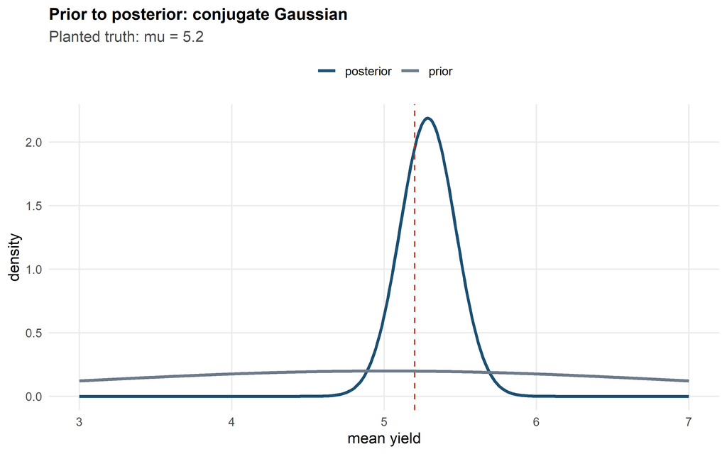

Figure 1: Prior (grey) and posterior (blue) for the mean: with n = 30 the likelihood dominates the prior, but the declared prior remains visible.

```r
mu_grid <- seq(3, 7, length.out = 400)
post_df <- data.frame(
  mu = rep(mu_grid, 2),
  density = c(stats::dnorm(mu_grid, 5, 2),
              stats::dnorm(mu_grid, post$mean[post$variable == "(Intercept)"],
                           post$sd[post$variable == "(Intercept)"])),
  distribution = rep(c("prior", "posterior"), each = length(mu_grid))
)
ggplot(post_df, aes(mu, density, colour = distribution)) +
  geom_line(linewidth = 1.1) +
  geom_vline(xintercept = verdade$bayes_small$mu, linetype = "dashed",
             colour = cores_smf[["alerta"]]) +
  scale_colour_manual(values = c(prior = cores_smf[["neutro"]],
                                 posterior = cores_smf[["primaria"]])) +
  labs(x = "mean yield", y = "density", colour = NULL,
       title = "Prior to posterior: conjugate Gaussian",
       subtitle = paste0("Planted truth: mu = ", fmt(verdade$bayes_small$mu, 1))) +
  theme(legend.position = "top")
```

```r
pr_bayes <- smf_bayes_predict(bf, bs[1:5, , drop = FALSE], ndraws = 500L)
cat("representation:", pr_bayes@representation,
    "| interval type:", pr_bayes@uncertainty@interval_type, "\n")
```

```
representation: samples | interval type: posterior_predictive
```

```r
ci_bayes <- smf_dist_interval(pr_bayes, level = 0.90)
tab_smf(data.frame(sample = bs$sample_id[1:5], mean = smf_dist_mean(pr_bayes),
                   lower = ci_bayes[, 1], upper = ci_bayes[, 2]),
        caption = "Posterior predictive distribution: mean and 90% interval for five new samples.")
```

Posterior predictive distribution: mean and 90% interval for five new samples.

| sample | mean | lower | upper |
| --- | --- | --- | --- |
| B01 | 5.188 | 3.604 | 6.704 |
| B02 | 5.266 | 3.601 | 6.817 |
| B03 | 5.281 | 3.552 | 6.924 |
| B04 | 5.294 | 3.651 | 7.011 |
| B05 | 5.275 | 3.507 | 6.916 |

```r
diag_bayes <- smf_bayes_diagnose(bf)
cat("diagnostic BayesFitResult:", class(diag_bayes)[1], "\n")
```

```
diagnostic BayesFitResult: sciModelFlowR::BayesianDiagnosticResult
```

```r
print(diag_bayes)
```

```
<sciModelFlowR BayesianDiagnosticResult>
  warnings: 0
```

**NoteInterpretation**

The posterior mean is 5.29 (truth 5.2) and the posterior SD is 0.98 (truth 1.1). The predictive interval is **posterior predictive**: it answers “where will a new observation fall”, not “where is the parameter”. Confusing the two is the most common error with Bayesian output — and the package carries the type in the object itself (`interval_type = "posterior_predictive"`).

## 1.1 GP and BART: functions the line cannot see

The Gaussian process smooths the organic-matter map in space; BART captures the nonlinear surface of the `dl_tiny` dataset.

```r
soil <- ler("soil_spatial")
set.seed(20260919); gp_order <- sample.int(nrow(soil), 70)
gx <- as.matrix(soil[gp_order[1:60], c("x", "y")])
gy <- soil$organic_matter[gp_order[1:60]]
gp <- smf_gp_fit(gx, gy, optimize = TRUE)
pr_gp <- smf_gp_predict(gp, as.matrix(soil[gp_order[61:70], c("x", "y")]))
rmse_gp <- sqrt(mean((soil$organic_matter[gp_order[61:70]] - smf_dist_mean(pr_gp))^2))
ud_gp <- smf_uncertainty_from_distribution(pr_gp)
tab_smf(data.frame(
  measure = c("GP RMSE (10 out-of-sample points)", "decomposition identified",
              "decomposition method"),
  value = c(fmt(rmse_gp, 3), as.character(ud_gp@identified), ud_gp@method)
), caption = "Spatial GP: out-of-sample error and identified uncertainty decomposition.")
```

Spatial GP: out-of-sample error and identified uncertainty decomposition.

| measure | value |
| --- | --- |
| GP RMSE (10 out-of-sample points) | 0.837 |
| decomposition identified | TRUE |
| decomposition method | bayesian_gp |

```r
dl <- ler("dl_tiny")
x_dl <- as.matrix(dl[, c("x1", "x2")]); y_dl <- dl$y
set.seed(20260919); i_tr <- sample.int(nrow(dl), 240)
bart <- smf_bart_fit(x_dl[i_tr, , drop = FALSE], y_dl[i_tr], task = "regression",
                     ndpost = 300L, nskip = 150L, ntree = 80L, seed = 1L)
pr_bart <- smf_bart_predict(bart, x_dl[-i_tr, , drop = FALSE])
rmse_bart <- sqrt(mean((y_dl[-i_tr] - smf_dist_mean(pr_bart))^2))
ci_bart <- smf_dist_interval(pr_bart, level = 0.90)
cov_bart <- mean(y_dl[-i_tr] >= ci_bart[, 1] & y_dl[-i_tr] <= ci_bart[, 2])
tab_smf(data.frame(
  model = c("BART", "straight line (lm)"),
  rmse = c(rmse_bart, sqrt(mean(lm(y ~ x1 + x2, data = dl[i_tr, ])$residuals^2)))
), caption = "Nonlinear surface: BART learns what the line cannot see (true noise: 0.15).")
```

Nonlinear surface: BART learns what the line cannot see (true noise: 0.15).

| model | rmse |
| --- | --- |
| BART | 0.202 |
| straight line (lm) | 0.742 |

# 2 Deep Learning with a reproducibility contract

The small MLP (2 -> 32 -> 16 -> 1) learns the planted surface. The training history is a first-class object, not a throwaway plot.

```r
architecture <- smf_mlp(input_dim = 2, output_dim = 1, hidden = c(32L, 16L),
                        activation = "relu", dropout = 0, task = "regression")
fit_dl <- smf_dl_train(x_dl[i_tr, , drop = FALSE], y_dl[i_tr],
                       architecture = architecture, epochs = 150L, batch_size = 32L,
                       seed = 20260919L)
history <- fit_dl@history
p_dl <- smf_dl_predict(fit_dl, x_dl[-i_tr, , drop = FALSE])
rmse_dl <- sqrt(mean((y_dl[-i_tr] - p_dl)^2))
tab_smf(data.frame(
  information = c("epochs executed", "best epoch", "best metric", "test RMSE"),
  value = c(history@stopped_epoch, history@best_epoch, history@best_metric, rmse_dl)
), caption = "MLP training record: what reproducibility requires.")
```

MLP training record: what reproducibility requires.

| information | value |
| --- | --- |
| epochs executed | 150.000 |
| best epoch | 150.000 |
| best metric | 0.092 |
| test RMSE | 0.327 |

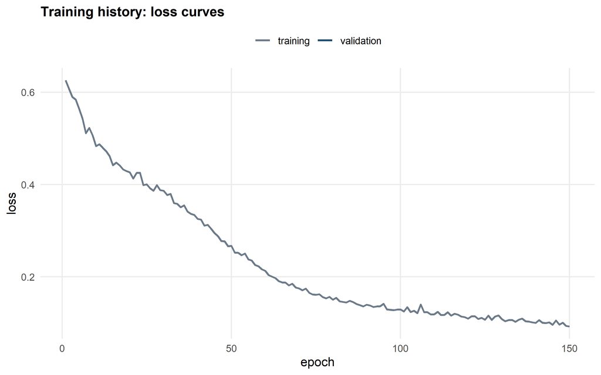

```r
hist_df <- data.frame(
  epoch = rep(history@epoch, 2),
  loss = c(history@training, history@validation),
  curve = rep(c("training", "validation"), each = length(history@epoch))
)
ggplot(hist_df, aes(epoch, loss, colour = curve)) +
  geom_line(linewidth = .9) +
  scale_colour_manual(values = c(training = cores_smf[["neutro"]],
                                 validation = cores_smf[["primaria"]])) +
  labs(x = "epoch", y = "loss", colour = NULL,
       title = "Training history: loss curves") +
  theme(legend.position = "top")
```

```r
dist_dl <- smf_dl_predict_distribution(fit_dl, x_dl[-i_tr, , drop = FALSE],
                                       method = "mc_dropout", draws = 50L)
ci_dl <- smf_dl_interval(dist_dl, level = 0.90)
cov_dl <- mean(y_dl[-i_tr] >= ci_dl[, 1] & y_dl[-i_tr] <= ci_dl[, 2])
refusal_dl <- tryCatch(
  smf_dl_uncertainty_decompose(dist_dl, level = 0.90),
  error = function(e) conditionMessage(e))
tab_smf(data.frame(
  measure = c("representation", "90% interval coverage", "decomposition"),
  value = c(dist_dl@representation, fmt(100 * cov_dl, 1), refusal_dl)
), caption = "MLP uncertainty: MC dropout samples and the honest refusal of the unidentified decomposition.")
```

MLP uncertainty: MC dropout samples and the honest refusal of the unidentified decomposition.

| measure | value |
| --- | --- |
| representation | samples |
| 90% interval coverage | 91.7 |
| decomposition | Sample variability alone does not identify aleatoric versus epistemic uncertainty; supply a model-based aleatoric component. |

```r
grad <- smf_dl_gradient_x_input(fit_dl, x_dl[-i_tr, , drop = FALSE][1:3, , drop = FALSE],
                                target_index = 1L)
tab_smf(data.frame(case = 1:3, x1 = x_dl[-i_tr, ][1:3, 1], x2 = x_dl[-i_tr, ][1:3, 2],
                   d_y_d_x1 = grad@values[, 1], d_y_d_x2 = grad@values[, 2]),
        caption = "Gradient explanation: sensitivity of the prediction to each input (local attribution, not causal).")
```

Gradient explanation: sensitivity of the prediction to each input (local attribution, not causal).

| case | x1 | x2 | d_y_d_x1 | d_y_d_x2 |
| --- | --- | --- | --- | --- |
| 1 | 0.100 | -0.144 | 0.495 | 0.111 |
| 2 | 0.435 | 0.275 | -2.010 | 0.183 |
| 3 | 0.108 | 0.385 | 0.574 | 0.168 |

**WarningTrap**

The package **refused** to decompose MC dropout uncertainty (Sample variability alone does not identify aleatoric versus epistemic uncertainty; supply a model-based aleatoric component.): sample variability alone does not separate aleatoric from epistemic. The honest output is the refusal, not an invented number. For an identified decomposition, use a model that separates the sources (such as the GP above).

# 3 Production: track, persist, serve

A scientific result must survive the session. The production flow has four steps: **record** (tracker), **freeze** (bundle), **serve** (batch prediction with resume) and **report** (manifest and report).

```r
field <- ler("field_yield")
v <- verdade$field_yield
no_out <- field[!field$plot_id %in% v$outlier_ids, ]
spec_p6 <- smf_experiment_spec(
  task = smf_task_spec("regression", "yield"),
  data = smf_data_spec("yield", c("nitrogen", "potassium", "water", "organic_matter"),
                       id_column = "plot_id"),
  design = smf_design_spec(id_column = "plot_id"),
  preprocessing = smf_preprocess_spec("median"),
  resampling = smf_resampling_spec("holdout", train_prop = 0.7, seed = 21L),
  model = smf_model_spec("linear_regression", "stats"),
  metrics = list(smf_metric_spec("rmse")),
  reproducibility = smf_reproducibility_spec(21L)
)
fit_p6 <- smf_fit_experiment(spec_p6, no_out)
```

```r
tr_dir <- file.path(tempdir(), "tracker-p6")
unlink(tr_dir, recursive = TRUE)
tr <- smf_tracker_local(tr_dir, experiment = "tutorial", tags = list(part = "6"))
run <- smf_start_run(tr, run_name = "final-model")
run <- smf_log_params(run, list(model = "linear_regression", n = nrow(no_out)))
run <- smf_log_metric(run, "rmse", fit_p6@metrics$value[fit_p6@metrics$metric == "rmse"])
run <- smf_log_result(run, fit_p6)
runs <- smf_list_runs(tr)
tab_smf(utils::head(runs[, c("run_id", "status", "started_at")], 5),
        caption = "Runs recorded in the local tracker (directory path omitted).")
```

Runs recorded in the local tracker (directory path omitted).

| run_id | status | started_at |
| --- | --- | --- |
| smf-20260919T035323-f65c60ad | running | 2026-09-19 03:53:23 UTC |

```r
cat("tracker directory:", gsub("\\\\", "/", tr_dir), "\n")
```

```
tracker directory: C:/Users/wep69/AppData/Local/Temp/RtmpU7Y3Fx/tracker-p6
```

```r
p_bundle <- file.path(tempdir(), "bundle-p6"); unlink(p_bundle, recursive = TRUE)
smf_save_bundle(fit_p6, p_bundle, mode = "portable")
val_bundle <- smf_validate_bundle(p_bundle)
bundle <- smf_load_bundle(p_bundle)
equal <- isTRUE(all.equal(as.numeric(smf_predict_bundle(bundle, no_out[1:7, ])),
                          as.numeric(smf_predict(fit_p6, no_out[1:7, ]))))
tab_smf(data.frame(
  check = c("valid bundle", "unsafe components", "prediction identical to the live path"),
  result = c(val_bundle@valid, length(val_bundle@unsafe_components), equal)
), caption = "Portable bundle: save, validate, load and predict with numerical equality.")
```

Portable bundle: save, validate, load and predict with numerical equality.

| check | result |
| --- | --- |
| valid bundle | 1 |
| unsafe components | 0 |
| prediction identical to the live path | 1 |

```r
ck_dir <- file.path(tempdir(), "batch-p6"); unlink(ck_dir, recursive = TRUE)
batch1 <- smf_batch_predict(fit_p6, no_out[1:20, ], batch_size = 7L, workers = 2L,
                            checkpoint_dir = ck_dir, resume = FALSE)
batch2 <- smf_batch_predict(fit_p6, no_out[1:20, ], batch_size = 7L, workers = 2L,
                            checkpoint_dir = ck_dir, resume = TRUE)
tab_smf(data.frame(
  measure = c("batch rows", "prediction column", "resume returns the same order",
              "second call marked as resumed"),
  value = c(batch1@n_rows, names(batch1@prediction)[1],
            identical(batch1@prediction$.prediction, batch2@prediction$.prediction),
            batch2@resumed)
), caption = "Batch prediction with checkpoint: resume reuses the work without redoing anything.")
```

Batch prediction with checkpoint: resume reuses the work without redoing anything.

| measure | value |
| --- | --- |
| batch rows | 20 |
| prediction column | .prediction |
| resume returns the same order | TRUE |
| second call marked as resumed | TRUE |

```r
dep <- smf_deployment_spec(adapter = "local", strict_schema = TRUE, batch_size = 128L)
scale <- smf_scalability_spec(chunk_size = 64L, workers = 2L, execution = "sequential",
                              checkpoint_every = 2L)
tab_smf(data.frame(
  contract = c("deployment: adapter", "deployment: strict schema",
               "scaling: chunk", "scaling: checkpoint every"),
  value = c(dep@adapter, dep@strict_schema, scale@chunk_size, scale@checkpoint_every)
), caption = "Deployment and scaling contracts declared as objects (not loose parameters).")
```

Deployment and scaling contracts declared as objects (not loose parameters).

| contract | value |
| --- | --- |
| deployment: adapter | local |
| deployment: strict schema | TRUE |
| scaling: chunk | 64 |
| scaling: checkpoint every | 2 |

# 4 Reporting and governance

The report is generated from the result, with a completeness checklist and a provenance manifest. Governance closes the cycle: deprecation policy and API catalogue.

```r
report <- smf_report(fit_p6, format = "markdown", title = "Complete tutorial — field trial")
report_file <- tempfile(fileext = ".md")
smf_report(fit_p6, format = "markdown", file = report_file)
```

```
<sciModelFlowR ReportingResult>
  format: markdown
  path: C:\Users\wep69\AppData\Local\Temp\RtmpU7Y3Fx\file749846a821a6.md
```

```r
checklist <- smf_reporting_checklist(fit_p6)
tab_smf(utils::head(checklist, 10), caption = "Reporting checklist: what was verified and what remains to be declared.")
```

Reporting checklist: what was verified and what remains to be declared.

| item | status | evidence |
| --- | --- | --- |
| scientific question/task | required | regression |
| experimental or sampling design | required | DesignSpec |
| data audit and leakage safeguards | required | DataAuditResult |
| resampling and final assessment separation | required | SplitRecord/ResampleCollection |
| preprocessing/feature provenance | required | FitResult state |
| model/backend and hyperparameters | required | stats linear_regression |
| performance with uncertainty | required | metrics/uncertainty |
| diagnostics | required | DiagnosticResult |
| calibration or conformal assumptions where used | conditional | typed calibration/conformal state |
| explanation limitations | conditional | causal_interpretation=FALSE |

```r
cat("report written:", basename(report_file), "|", file.size(report_file), "bytes\n")
```

```
report written: file749846a821a6.md | 2310 bytes
```

```r
policy <- smf_deprecation_policy()
tab_smf(data.frame(
  item = c("API freeze", "stable release", "policy"),
  value = c(policy$api_freeze, policy$stable_release, policy$policy)
), caption = "Current deprecation policy: the API frozen at 1.0.0 does not change without a documented lifecycle.")
```

Current deprecation policy: the API frozen at 1.0.0 does not change without a documented lifecycle.

| item | value |
| --- | --- |
| API freeze | 1.0.0 |
| stable release | 1.0.2 |
| policy | No public symbol stable at 1.0.0 is removed or changes scientific meaning in 1.x without an explicit lifecycle, migration path, and validation evidence. |

```r
cat("manifest available:", !is.null(smf_manifest(fit_p6)), "\n")
```

```
manifest available: TRUE
```

# 5 Synthesis: the complete flow in one table

| Step | Question | Central tool | Evidence |
| --- | --- | --- | --- |
| 1. Declare | What are the target, unit and design? | `smf_data_spec`, `smf_design_spec` | contracts refuse misuse |
| 2. Audit | What is discrepant? | `smf_audit_data` + manual diagnostics | missingness, outliers, heteroscedasticity |
| 3. Resample | What is a “new observation”? | `smf_group_vfold_cv`, `smf_time_cv`, `smf_spatial_cv` | leakage measured, not presumed |
| 4. Prepare | Impute? Centre? Balance? | `smf_fit_preprocessor`, `smf_apply_imbalance` | declared and stress-tested decisions |
| 5. Model | What is the functional form? | `smf_fit_experiment` | truth recovered, residuals diagnosed |
| 6. Compare | Which configuration/model? | `smf_tune`, `smf_benchmark` | same resample, explicit rule |
| 7. Explain | What does the model use? | `smf_permutation_importance`, `smf_pdp`, `smf_ale` | stability across folds |
| 8. Measure uncertainty | How much to trust? | conformal, bootstrap, Bayes/GP | measured coverage, typed semantics |
| 9. Serve | How to deploy without losing the model? | bundle, batch, tracker | live vs bundle equality |
| 10. Report | What was recorded? | `smf_report`, manifest | checklist and provenance |

# 6 Appendix A — API coverage, computed

The code below reads this tutorial’s own files and measures how many of the 246 exported functions were **called**, per category. It is a measure of the material, not a promise.

```r
files <- list.files("en", pattern = "^part-.*\\.qmd$", full.names = TRUE)
code <- paste(unlist(lapply(files, readLines, warn = FALSE)), collapse = "\n")
calls <- unique(unlist(regmatches(code, gregexpr("smf_[a-zA-Z0-9_]+", code))))
api <- smf_api_catalog()
covered <- intersect(calls, api$function_name)
missing_fns <- setdiff(api$function_name, covered)
cov_cat <- as.data.frame(table(api$category[api$function_name %in% covered]))
names(cov_cat) <- c("category", "called")
cov_cat$total <- as.integer(table(api$category))
cov_cat$fraction <- cov_cat$called / cov_cat$total
cov_cat <- cov_cat[order(-cov_cat$called), ]
tab_smf(cov_cat, caption = "Functions called in this tutorial, by API category.")
```

Functions called in this tutorial, by API category.

|  | category | called | total | fraction |
| --- | --- | --- | --- | --- |
| 1 | core | 34 | 88 | 0.386 |
| 6 | modeling | 26 | 35 | 0.743 |
| 5 | inference-uncertainty | 13 | 24 | 0.542 |
| 9 | resampling-features | 9 | 23 | 0.391 |
| 3 | deep-learning | 6 | 23 | 0.261 |
| 7 | operations | 6 | 17 | 0.353 |
| 8 | reporting-validation | 5 | 11 | 0.455 |
| 10 | tuning-benchmark | 5 | 10 | 0.500 |
| 2 | data-design | 4 | 9 | 0.444 |
| 4 | explainability | 4 | 6 | 0.667 |

```r
cat("called:", length(covered), "of", nrow(api), "exported functions (",
    fmt(100 * length(covered) / nrow(api), 1), "% )\n")
```

```
called: 112 of 246 exported functions ( 45.5 % )
```

```r
gap_tbl <- data.frame(
  category = api$category[match(missing_fns, api$function_name)],
  function_name = missing_fns
)
gap_tbl <- gap_tbl[order(gap_tbl$category, gap_tbl$function_name), ]
tab_smf(gap_tbl, caption = "Exported functions not called in this tutorial, by category (each has its own vignette or help page).")
```

Exported functions not called in this tutorial, by category (each has its own vignette or help page).

|  | category | function_name |
| --- | --- | --- |
| 2 | core | smf_autoencoder |
| 4 | core | smf_backend_capabilities |
| 14 | core | smf_blocked_cv |
| 17 | core | smf_check_pseudoreplication |
| 18 | core | smf_chunk_plan |
| 19 | core | smf_cnn1d |
| 20 | core | smf_cnn2d |
| 27 | core | smf_dist_cdf |
| 28 | core | smf_dist_median |
| 29 | core | smf_dist_sample |
| 30 | core | smf_dist_sd |
| 31 | core | smf_dist_variance |
| 50 | core | smf_end_run |
| 53 | core | smf_explanation_agreement |
| 54 | core | smf_explanation_domain |
| 55 | core | smf_export_onnx |
| 59 | core | smf_from_json |
| 60 | core | smf_from_list |
| 61 | core | smf_get_run |
| 62 | core | smf_gru |
| 64 | core | smf_hash |
| 68 | core | smf_list_datasets |
| 69 | core | smf_load_dataset |
| 70 | core | smf_log_artifact |
| 71 | core | smf_lstm |
| 75 | core | smf_monte_carlo_cv |
| 76 | core | smf_multimodal |
| 77 | core | smf_multitask |
| 80 | core | smf_param_dbl |
| 81 | core | smf_param_fct |

[output cut: 104 more lines]

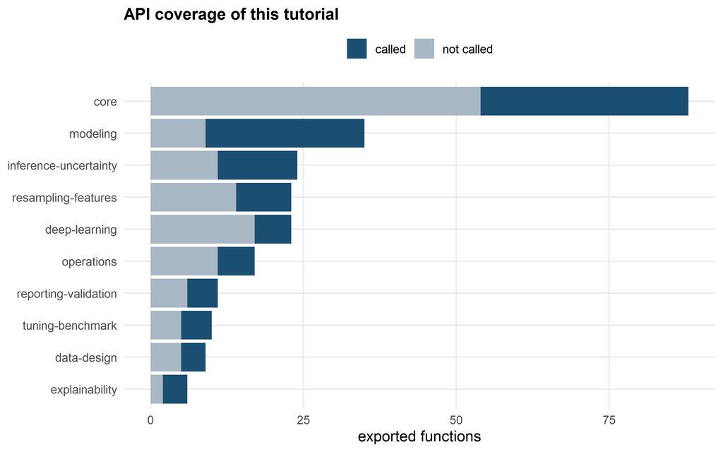

Figure 3: API coverage by category: the gaps are declared, not hidden.

```r
cov_long <- data.frame(
  category = rep(cov_cat$category, 2),
  type = rep(c("called", "not called"), each = nrow(cov_cat)),
  n = c(cov_cat$called, cov_cat$total - cov_cat$called)
)
ggplot(cov_long, aes(stats::reorder(category, n), n, fill = type)) +
  geom_col(position = "stack") +
  coord_flip() +
  scale_fill_manual(values = c(called = cores_smf[["primaria"]],
                               `not called` = cores_smf[["claro"]])) +
  labs(x = NULL, y = "exported functions", fill = NULL,
       title = "API coverage of this tutorial") +
  theme(legend.position = "top")
```

**NoteReading**

The uncalled functions belong mostly to three groups: (1) variants for structures that require specific data (DL tensors, `smf_dl_train_tensor`, `smf_dl_gradcam` for images); (2) optional backends that require external packages (`smf_tracker_mlflow`, `smf_conformal_probably`); (3) governance and catalogue utilities (`smf_release_candidate_audit`, `smf_backend_matrix` already used in Part 1). Every gap has a reason — and the reason is declared, as the material’s principle demands.

# 7 Appendix B — Minimal glossary

| Term | Operational definition |
| --- | --- |
| **Contract** | Explicit declaration the package verifies at execution; violating it raises an error, not a warning. |
| **Leakage** | Evaluation information used to build the model; produces optimistic metrics. |
| **Resampling** | Procedure that defines what counts as a new observation (holdout, folds, groups, time, space). |
| **Fold-safe preprocessing** | Statistics (median, scale) estimated only on each fold’s training data. |
| **Imbalance** | Classes with very different frequencies; accuracy stops being a useful metric. |
| **Calibration** | Agreement between declared probability and observed frequency (ECE measures the gap). |
| **Coverage** | Frequency with which the interval contains the true value; the conformal guarantee is marginal. |
| **Aleatoric uncertainty** | Irreducible variability of the phenomenon. |
| **Epistemic uncertainty** | Model ignorance, reducible with more data. |
| **Bundle** | Self-contained artefact (model + preprocessing + metadata) for inference outside the session. |
| **Manifest** | Provenance record: hashes, versions, seeds and decisions of a run. |

# 8 Appendix C — Execution environment

```r
cat("sciModelFlowR:", as.character(packageVersion("sciModelFlowR")), "\n")
```

```
sciModelFlowR: 1.0.2
```

```r
cat("R:", R.version.string, "\n")
```

```
R: R version 4.6.0 (2026-04-24 ucrt)
```

```r
cat("platform:", R.version$platform, "\n")
```

```
platform: x86_64-w64-mingw32
```

```r
cat("core packages:", paste(c("ggplot2", "knitr", "patchwork"), collapse = ", "), "\n")
```

```
core packages: ggplot2, knitr, patchwork
```

```r
cat("executed at:", format(Sys.time(), "%Y-%m-%d %H:%M"), "\n")
```

```
executed at: 2026-09-19 00:53
```

# 9 Part 6 exercises

**NoteExercise 6.1 — Prior strength**

Refit the conjugate model with `beta_sd = c(0.5)` (tight prior) and with `beta_sd = c(20)` (wide prior). Compare the posteriors with the truth (5.2). With n = 30, does the prior still matter?

**NoteExercise 6.2 — GP with fixed hyperparameters**

Run the GP with `optimize = FALSE` and `length_scale = 0.05`. Does RMSE get worse? What does this teach about the spatial range scale (truth: 0.25)?

**NoteExercise 6.3 — BART versus MLP**

Compare BART and MLP on the same `dl_tiny` split (RMSE and time). In which situation would you prefer each one?

**NoteExercise 6.4 — Opaque bundle**

Save the same model in `opaque` mode, try to load it without `trusted = TRUE` and read the error. Then load it with explicit trust and check prediction equality. Why must trust be explicit?

**CautionSolutions**

**6.1.** With a tight prior (0.5), the posterior is pulled toward 5.0; with a wide prior (20), it stays close to the likelihood (~5.3). With n = 30, the prior still moves the result — the size of the effect depends on the ratio between prior information and data.

**6.2.** With range 0.05 (smaller than the true 0.25), the GP sees no correlation between neighbours and falls back to the mean level; RMSE rises. The range is a **scientific hyperparameter**, not a technical detail.

**6.4.** The opaque bundle loads native objects that can execute code; `trusted = TRUE` is the explicit signature of trust. The error without the argument is the security boundary working.